# Progression of Disease section

Author

Natallia

Published

May 3, 2026

Definition of the variables: - treatment indicator (0 = ZDV only; 1 = ZDV + ddI, 2 = ZDV + Zal, 3 = ddI only) - hemo hemophilia (0=no, 1=yes) - drugs history of IV drug use (0=no, 1=yes) - oprior Non-ZDV antiretroviral therapy pre-175 (0=no, 1=yes)

```r
# hist(features$time/7)
# quantile(features$time/7) #143 is the median treatment weeks
#
# quantile(features$time)
#   0%  25%  50%  75% 100%
#   14  727  997 1091 1231
# > 1231/365
# [1] 3.372603
# > 997/365
# [1] 2.731507 => average 2.7 years treatment

#str2 antiretroviral history (0=naive, 1=experienced)
# features$str2<-factor(features$str2, levels=c(0,1), labels=c("naive", "experienced"))
# tapply(features$time/7, features$str2, median)
```

[output not shown]

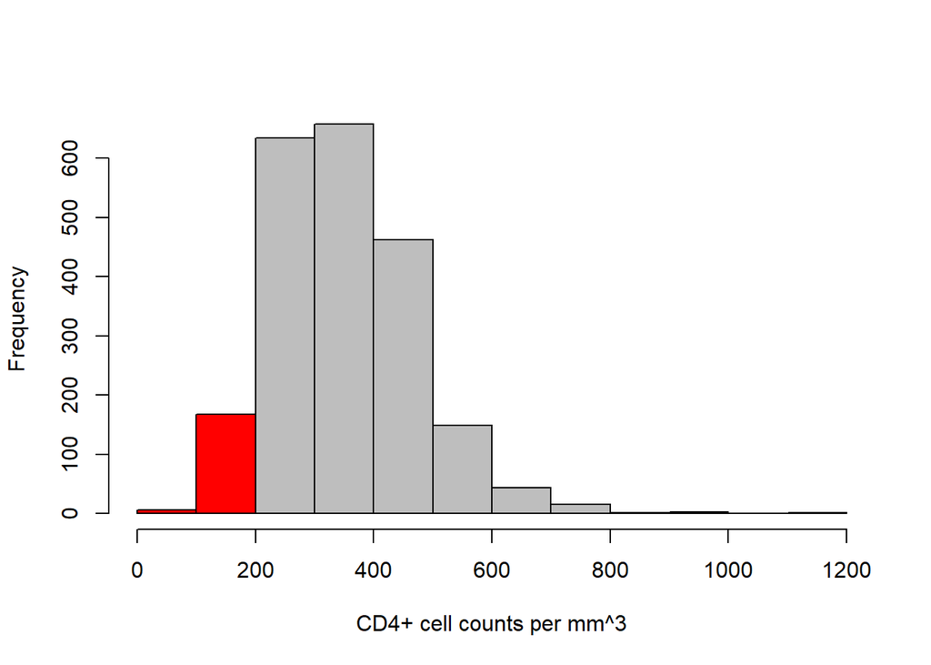

Figure 1: Baseline distribution of CD4+ cell counts per mm^3

As we can see from the histogram there appear to be people with less than 200 CD4+ cells per mm^3 which would be against the criteria mentioned in the paper. (7.667 %)

**Note**

Death can not be determined. As well as the cd40 counts at baseline include <200 cells per mm3 which does not make sense!!

# 1st Paragraph

*Five hundred sixty-five patients reached a primary end point — a 50 percent decline in the CD4 cell count, an AIDS-defining event, or death.*

```r
prim<-table(features$cid)

#of these how many in prior antiretroviral therapy (1,0)
features$str2<-factor(features$str2, levels=c(0,1), labels=c("no", "yes"))
prim_str2<-table(features$cid, features$str2)

prim_str2[2,1]/prim[2] #NO antiretroviral
prim_str2[2,2]/prim[2] #antiretroviral
```

[output not shown]

We got 521 people who reached the primary endpoint. (24.357 %)

# 2nd paragraph

*“Sixty-nine percent of these patients were in the subgroup with prior antiretroviral therapy, and 31 percent in the subgroup with no prior antiretroviral therapy.”*

Just as the paper described we’ve got similar results considering the percentages of people with/or without prior antiretroviral therapy out of the ones who reached the primary endpoint: 69.29% btw 30.71%.

# 3rd paragraph

*End points related to the CD4 cell count constituted the majority of the first events (399 of 565, or 71 percent).*

```r
(table(features$cid, features$cd420/features$cd40<=0.5|features$cd420<200))

135/prim[2]
# 0.2591171
```

In our analysis we could only find 25.912% of the primary endpoints related to CD4+ cells in both vases of decrease more than 50% and the AIDS phase with CD4+<200 cells per mm3.

# 4th paragraph

*In 75 percent of cases the primary end point was reached during treatment or within three months of its discontinuation; in 15 percent of cases the end point was reached more than one year after treatment was discontinued. Of the clinical (secondary) end points of an AIDS-defining event or death or death alone, 50 and 25 percent, respectively, occurred during treatment or within three months after its discontinuation; 25 and 35 percent, respectively, occurred more than one year after its discontinuation.*

**Note**

Impossible to determine this percentages -> only 1 time variable, we can not see the follow-up or discontinuation of the treatment point

# Figures reproduced: Figure 1 A, B

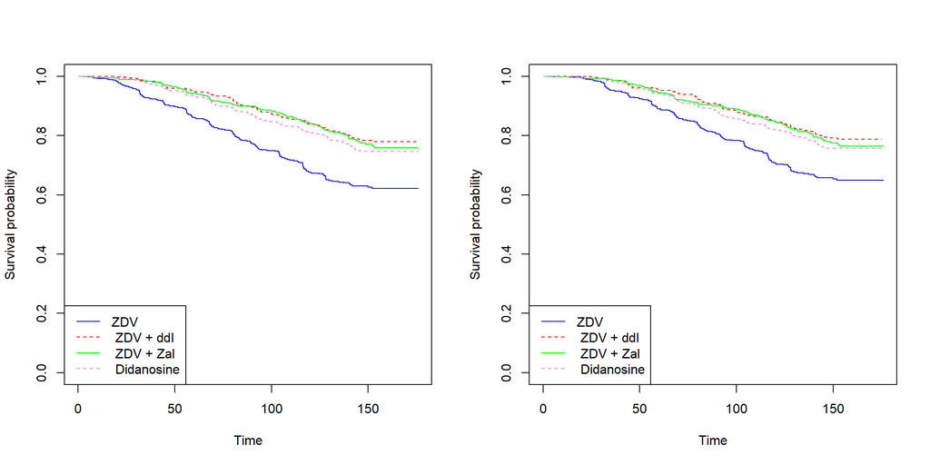

Figure 2: Kaplan-Meier Estimates of the Proportion of Patients Not Reaching the Primary Endpoint (A) or the Secondary Endpoint(B)

```r
#1. Kaplan Meier
library(survival)

surv_obj1 <- Surv(time = features$time/7, event = features$cid)
km_fit1 <- survfit(surv_obj1 ~ trt, data = features)



features$sec_endpoint_maybe<-ifelse(features$cid==1 & features$cd420/features$cd40>0.5,1,0)


surv_obj2 <- Surv(time = features$time/7, event = features$sec_endpoint_maybe)
km_fit2 <- survfit(surv_obj2 ~ trt, data = features)


par(mfrow=c(1,2))
plot(km_fit1, col = c("blue", "red", "green", "violet"), lty = 1:2,
     xlab = "Time", ylab = "Survival probability", ylim = c(0,1))
legend("bottomleft", legend = c("ZDV"," ZDV + ddI"," ZDV + Zal"," Didanosine"),
       col = c("blue", "red", "green", "violet"), lty = 1:2)


plot(km_fit2, col = c("blue", "red", "green", "violet"), lty = 1:2,
     xlab = "Time", ylab = "Survival probability", ylim = c(0,1))
legend("bottomleft", legend = c("ZDV"," ZDV + ddI"," ZDV + Zal"," Didanosine"),
       col = c("blue", "red", "green", "violet"), lty = 1:2)
```

```r
# 2. log-rank test
log_rank_1<-survdiff(Surv(time/7, cid) ~trt, features)
log_rank_2<-survdiff(Surv(time/7, sec_endpoint_maybe) ~trt, features)
```

Log Rank test looks if there is a difference between the KM curves. Null-Hypothesis says there is no difference and thus we want to disprove it. Use Chi squared as we have count/categorical data. (For continuos data we use F test.)

```r
#pairwise long rank test
library(survival)
library(survminer)
pairwise_survdiff(
  Surv(time/7, cid) ~ trt,
  data = features,
  p.adjust.method = "bonferroni"
)
```

```
    Pairwise comparisons using Log-Rank test

data:  features and trt

                           Zidovudine Zidovudine and Didanosine
Zidovudine and Didanosine  3.6e-08    -
Zidovudine and Zalcitabine 4.8e-07    1
Didanosine                 2.2e-05    1
                           Zidovudine and Zalcitabine
Zidovudine and Didanosine  -
Zidovudine and Zalcitabine -
Didanosine                 1

P value adjustment method: bonferroni
```

```r
# 3. Cox proportionality hazard model stratified by strat
cox_1<-coxph(Surv(time/7, cid)~trt + strata(strat), features)
cox_2<-coxph(Surv(time/7, sec_endpoint_maybe)~trt + strata(strat), features)
```

It models how different variables affect the risk of an event over time. In model 1 we can see that treatment 1 (ZZI + ddI) has the lowest risk to develop the event CID of hazard ratio of 0.486 thus a 51.4% lower risk. For model 2 with the secondary endpoint we see that also treatment 1 has the lowest risk. (0.52 thus 48% lower risk)

```r
# 4. Cox "" with interaction term for diff strat
cox_inter_1<-coxph(Surv(time/7, cid)~trt * strat, features)
cox_inter_2<-coxph(Surv(time/7, sec_endpoint_maybe)~trt *strat, features)
```

Treatment 1 showed significant protective effect in Kaplan Meier, log-rank test and simple Cox models, but was not statistically significant in the interaction model, likely due to reduced precision from additional parameters. Overall, results show a consistent protective effect of treatment 1.

# Reconstructing the Table 2 with analysis results

```r
library(gtsummary)

#compute N and (%)
library(dplyr)
n_trt<- features %>%
  filter(cid==1)%>%
  count(trt) %>%
  mutate(
    pct=n/sum(n)*100,
    n_pct = sprintf("%d (%.0f)", n, pct)
  )

#compute regression tables

tbl_1<-tbl_regression(cox_1, exponentiate = T,
  label = list(trt ~ "Treatment"))%>%
  add_global_p()%>%
  modify_header(label ~ "")


tbl_2<-tbl_regression(cox_2, exponentiate = T,
  label = list(trt ~ "Treatment"))%>%
  add_global_p()%>%
  modify_header(label ~ "")%>%
    modify_table_styling(
    columns = label,
    align = "left",
  ) %>%
  modify_table_body(
    ~ .x %>%
      left_join(n_trt, by = c("label" = "trt"))
  )

tbl_2 <-
  tbl_2 %>%
  modify_header(n_pct ~ "N (%)")


tbl_merge(
  tbls = list(tbl_1, tbl_2),
  tab_spanner = c("Primary Endpoint", "Secondary Endpoint")
)
```

Table 1: Rates of Disease progression

|  | Primary Endpoint **HR** | Primary Endpoint **95% CI** | Primary Endpoint **p-value** | Secondary Endpoint **HR** | Secondary Endpoint **95% CI** | Secondary Endpoint **p-value** | Secondary Endpoint N (%) |
| --- | --- | --- | --- | --- | --- | --- | --- |
| Treatment |  |  | <0.001 |  |  | <0.001 |  |
| Zidovudine | — | — |  | — | — |  | 181 (35) |
| Zidovudine and Didanosine | 0.49 | 0.38, 0.62 |  | 0.52 | 0.40, 0.67 |  | 103 (20) |
| Zidovudine and Zalcitabine | 0.52 | 0.41, 0.66 |  | 0.57 | 0.44, 0.73 |  | 109 (21) |
| Didanosine | 0.58 | 0.47, 0.73 |  | 0.62 | 0.49, 0.79 |  | 128 (25) |

Abbreviations: CI = Confidence Interval, HR = Hazard Ratio